# STSCI 5065 - Lecture 10

Introduction to Apache Hive - Part 3: HiveQL Data Query Language (DQL)

Harry Lu

# 1 What Does Hive DQL Include and Do?

- The `SELECT`, `SHOW` and `HELP` statements (queries)
- `SELECT` is the main DQL instruction. It retrieves data you need
- `SHOW` retrieves info about the metadata
- `HELP` is for people who need help

# 2 `SELECT ... FROM` Clauses

- The `SELECT` clause specifies the columns to keep, as well as the outputs of function calls on one or more columns, e.g., the aggregation functions like `count(*)`
- The `FROM` clause identifies from which table, view, or nested query we select records
- For example:

```
SELECT e.name, e.salary FROM employees e;
```

## 2.1 JSON Syntax For a Collection Type

Hive uses JSON (Java-Script Object Notation) syntax for the output:

```
hive> select name, subordinates from employees20;
OK
John Smith  ["Mary Smith","David Wells"]
Mary Smith  ["Bill King"]
Jason Yang  ["Diana Foster","Kelli Doe","Kevin Hoover"]
Ted Wang    ["Diana Johnson","Kevin Li","Dan Jones"]
Mike McPheron   ["Marvin Xu","Elise Lee"]
```

```
hive> select name, deductions from employees20;
OK
John Smith  {"Federal Taxes":0.2,"State Taxes":0.05,"Insurance":0.1}
Mary Smith  {"Federal Taxes":0.2,"State Taxes":0.05,"Insurance":0.1}
Jason Yang  {"Federal Taxes":0.2,"State Taxes":0.05,"Insurance":0.1}
Ted Wang    {"Federal Taxes":0.2,"State Taxes":0.05,"Insurance":0.1}
Mike McPheron   {"Federal Taxes":0.02,"State Taxes":0.05,"Insurance":0.1}
```

```
hive> select name, address from employees20;
OK
John Smith  {"street":"1 Michigan Ave.","city":"Chicago","state":"IL","zip":60600}
Mary Smith  {"street":"100 Ontario St.","city":"Chicago","state":"IL","zip":60601}
Jason Yang  {"street":"101 Uptown Rd.","city":"Ithaca","state":"NY","zip":14850}
Ted Wang    {"street":"21 Farm Rd.","city":"Ithaca","state":"NY","zip":14850}
Mike McPheron   {"street":"12 Bush Ave.","city":"Ithaca","state":"NY","zip":14850}
```

## 2.2 Use Ambari Hive View to Do a Query

```
SELECT name, deductions FROM employees20;
```

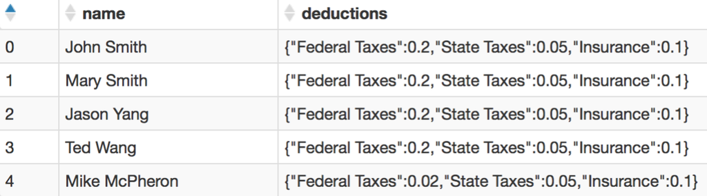

```
SELECT name, address FROM employees20;
```

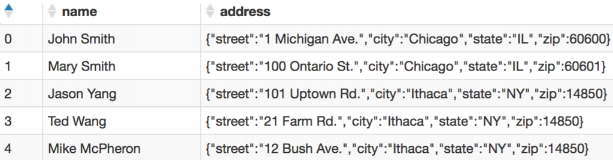

## 2.3 Reference Elements of Collections: Array (Use Indexes)

```
SELECT name, subordinates[0] FROM employees20;
```

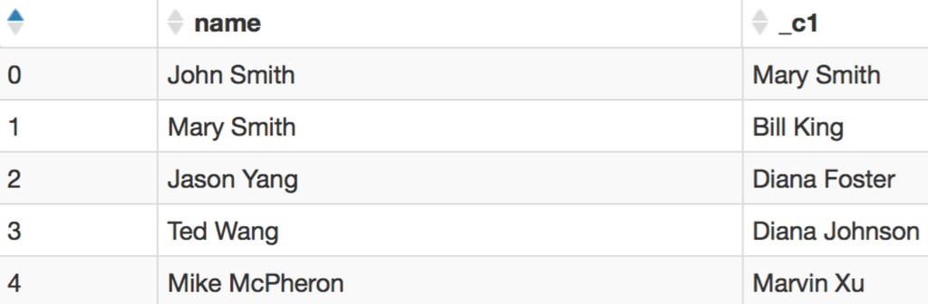

```
hive> select name, subordinates[0] from employees20;
OK
John Smith  Mary Smith
Mary Smith  Bill King
Jason Yang  Diana Foster
Ted Wang    Diana Johnson
Mike McPheron   Marvin Xu
```

## 2.4 What will Happen to the Query if

- an employee does not have a subordinate?
- an employee does not have as many subordinates?
1. It causes an error in query and stops processing
2. It causes an error in query and completes processing
3. It does not cause an error but produces a NULL for any of such situations
4. It does not cause an error but produces an empty string for any of such situations

## 2.5 An Employee does not Have a Subordinate

```
John Smith^100000.0^Mary Smith#David Wells^Federal Taxes@0.2#State Taxes@0.05#Insurance@0.1^1 Michigan Ave.#Chicago#IL#60600
Mary Smith^80000.0^Bill King^Federal Taxes@0.2#State Taxes@0.05#Insurance@0.1^100 Ontario St.#Chicago#IL#60601
Jason Yang^150000.0^Diana Foster#Kelli Doe#Kevin Hoover^Federal Taxes@0.2#State Taxes@0.05#Insurance@0.1^101 Uptown Rd.#Ithaca#NY#14850
Ted Wang^120000.0^^Federal Taxes@0.2#State Taxes@0.05#Insurance@0.1^21 Farm Rd.#Ithaca#NY#14850
Mike McPheron^150000.0^^Federal Taxes@0.02#State Taxes@0.05#Insurance@0.1^12 Bush Ave.#Ithaca#NY#14850
```

The last two employees do not have a subordinate, so the data file must contain appropriate delimiters, in this case, `^`

## 2.6 Reference Elements of Collections: Array

```
SELECT name, subordinates[0] FROM employees10;
```

```
hive> select name, subordinates[0] from employees10;
OK
John Smith  Mary Smith
Mary Smith  Bill King
Jason Yang  Diana Foster
Ted Wang    NULL
Mike McPheron   NULL
```

```
SELECT name, subordinates[3] FROM employees10;
```

```
hive> select name, subordinates[3] from employees10;
OK
John Smith  NULL
Mary Smith  NULL
Jason Yang  NULL
Ted Wang    NULL
Mike McPheron   NULL
```

## 2.7 Reference Elements of Collections: Map (Use a Key)

```
SELECT name, deduction["Insurance"] FROM employees10;
```

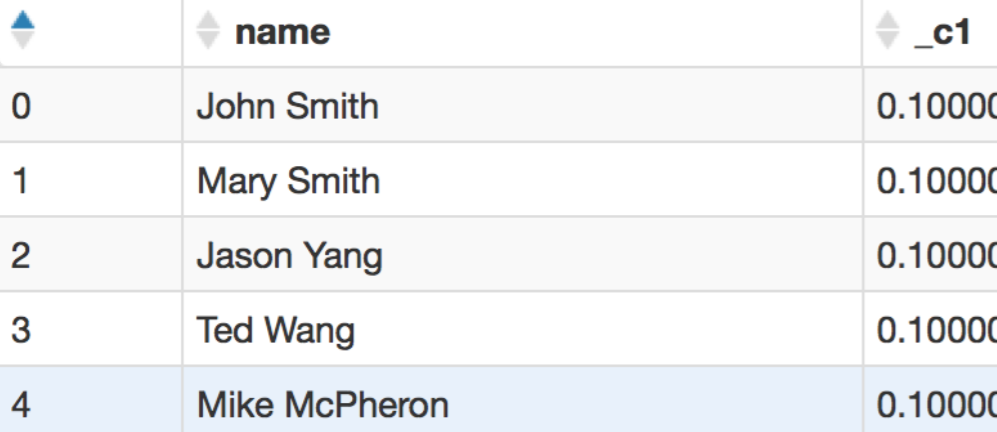

```
hive> select name, deductions["Insurance"] from employees10;
OK
John Smith  0.1
Mary Smith  0.1
Jason Yang  0.1
Ted Wang    0.1
Mike McPheron   0.1
```

## 2.8 Reference Elements of Collections: Struct (Use Dot Notation)

```
SELECT name, address.city, address.state FROM employees10;
```

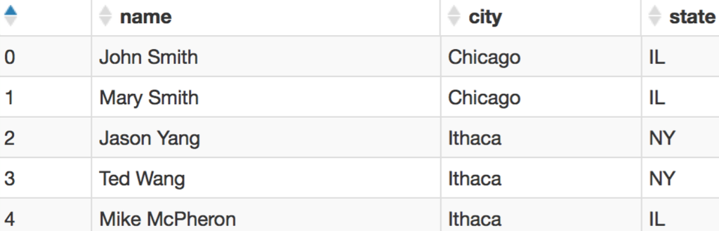

```
hive> select name, address.city, address.state from employees10;
OK
John Smith  Chicago IL
Mary Smith  Chicago IL
Jason Yang  Ithaca  NY
Ted Wang    Ithaca  NY
Mike McPheron   Ithaca  IL
```

## 2.9 Computing with Column Values

**To do:** select the employees’ names converted to uppercase, their salaries, actual amount paid after the deductions, rounded to two decimal points

```
SELECT upper(name), salary, round(salary * (1 - deductions["Federal Taxes"] - deductions["State Taxes"] - deductions["Insurance"]), 2)
FROM employees23;
```

```
hive> select upper(name), salary, round(salary * (1 - deductions["Federal Taxes"]
    > - deductions["State Taxes"] - deductions["Insurance"]), 2) from employees23;
OK
JOANN FRASER    100000.0    65000.0
ELISE SMITH 80000.0 52000.0
JASON YANG  150000.0    97500.0
TED WANG    190000.0    123499.99
TOM MCPHERON    210000.0    174300.0
JOHN SMITH  100000.0    65000.0
MARY SMITH  80000.0 52000.0
JASON JONES 150000.0    97500.0
BOB MCPHERON    150000.0    124500.0
SAM JOHNSON 100000.0    65000.0
ELISE SMITH 80000.0 52000.0
JASON YANG  150000.0    97500.0
TED WANG    120000.0    78000.0
TOM MCPHERON    150000.0    124500.0
```

# 3 Hive Built-in Functions

- Hive has a large number of built-in functions. The reference can be found at the following link: https://cwiki.apache.org/confluence/display/Hive/LanguageManual+UDF#LanguageManualUDF-Built-inFunctions
- There are many types of functions:
  - Basic mathematical functions
  - Aggregate functions
  - String functions
  - Map functions
  - Array functions
  - Timestamp functions
  - …

## 3.1 Important Built-in Math Functions

| Return type | Function | Description |
| --- | --- | --- |
| BIGINT | `round(d)` | Return BIGINT for the rounded value of DOUBLE `d` |
| DOUBLE | `round(d, N)` | Return DOUBLE for value `d`, rounded to `N` decimal places |
| DOUBLE | `exp(d)` | Return e to the `d` |
| DOUBLE | `ln(d)` | Return the natural logarithm of `d` |
| DOUBLE | `log10(d)` | Return the base-10 logarithm of `d` |
| DOUBLE | `log2(d)` | Return the base-2 logarithm of `d` |
| DOUBLE | `log(base, d)` | Return the base-`base` logarithm of `d` |
| DOUBLE | `pow(d, p)`, `power(d, p)` | Return `d` raised to the power `p` |
| DOUBLE | `sqrt(d)` | Return the square root of `d` |
| DOUBLE | `abs(d)` | Return the absolute value of `d` |
| DOUBLE | `degrees(d)` | Return the value of `d` converted from radians to degrees |
| DOUBLE | `radians(d)` | Return the value of `d` converted from degrees to radians |
| DOUBLE | `pi()` | Return the value of constant pi, 3.141592653589793 |

## 3.2 Important Built-in Aggregate Functions

| Return type | Function | Description |
| --- | --- | --- |
| BIGINT | `count(*)` | Return the total number of retrieved rows, including rows containing NULL values |
| BIGINT | `count(expr)` | Return the number of rows for which the supplied expression is not NULL |
| BIGINT | `count(DISTINCT expr[, expr_.])` | Return the number of rows for which the supplied expression(s) are unique and not NULL |
| DOUBLE | `sum(col)`, `sum(DISTINCT col)` | Return sum of the elements or sum of distinct values in a group |
| DOUBLE | `avg(col)`, `avg(DISTINCT col)` | Return average of the elements or average of distinct values in a group |
| DOUBLE | `min(col)`, `max(col)` | Return the minimum or maximum of the values |
| DOUBLE | `variance(col)` | Return variance of a set of numbers |
| DOUBLE | `var_samp(col)` | Return the sample variance of a set of numbers |
| DOUBLE | `stddev_pop(col)` | Return standard deviation of a set of numbers |
| DOUBLE | `stddev_samp(col)` | Return sample standard deviation of a set of num |
| . | `corr(col1, col2)` | Return the correlation of two sets of numbers |
| ARRAY | `collect_set(col)` | Return a set with duplicate elements removed |

## 3.3 Other Built-in Functions

| Return type | Function | Description |
| --- | --- | --- |
| BOOLEAN | `test in(va1, val2, ...)` | Return true if test is one of the values in the list |
| INT | `length(s)` | Return the length of the string |
| STRING | `reverse(s)` | Return a reverse copy of the string |
| STRING | `concat(s1, s2, ...)` | Return a concatenation of `s1`, `s2`, `...` |
| STRING | `concat_ws(separator , s1, s2, ...)` | Like concat, but using the specified separator |
| STRING | `substr(s, start_index)` | Return the substring of `s` from `start_index` position, where 1 is the index of the first character, to the end |
| STRING | `substr(s, int start, int length)` | Return the substring of `s` starting from the `start` position with the given `length` |
| STRING | `trim(s)` | Return string by removing whitespace at both ends |
| INT | `size(map)`, `size(array)` | Return the number of elements in the map or array |
| <type> | `cast(expr as type)` | Convert (“cast”) the result of the `expr` to `type` |
| ARRAY<STR> | `split(s, pattern)` | Returns an array of substrings of `s`, split at `pattern` |
| INT | `instr(str, substr)` | Returns the index of `str` where `substr` is found |
| MAP<S, S> | `str_to_map(s, d1, d2)` | Creates a map, `d1` for k-v pairs, `d2` for k-v separators |

# 4 `LIMIT` Clause

The `LIMIT` clause puts an upper limit on the number of rows returned by a query

```
SELECT upper(name), salary, round(salary * (1 - deductions["Federal Taxes"] - deductions["State Taxes"] - deductions["Insurance"]), 2)
FROM employees23
LIMIT 5;
```

```
JOANN FRASER    100000.0    65000.0
ELISE SMITH 80000.0 52000.0
JASON YANG  150000.0    97500.0
TED WANG    190000.0    123499.99
TOM MCPHERON    210000.0    174300.0
```

# 5 Column Aliases

We can give anonymous columns a name, called a column alias, in a query

```
SELECT name, salary, round(salary * (1 - deductions["Federal Taxes"] - deductions["State Taxes"] - deductions["Insurance"]), 1) as Actually_Paid
FROM employees23
LIMIT 10;
```

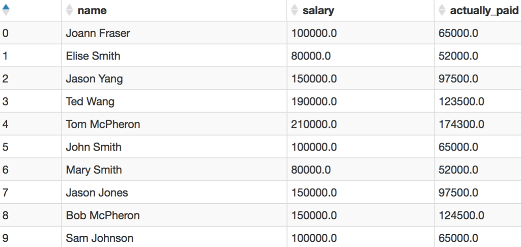

# 6 Nested `SELECT` Statements

The result of one query is used by another query

The column alias feature is especially useful in nested select statements

```
FROM (
  SELECT name, salary, round(salary * (1 - deductions["Federal Taxes"] - deductions["State Taxes"] - deductions["Insurance"]), 1) as Actually_Paid
  FROM employees23
) ap
SELECT ap.name, ap.Actually_Paid
WHERE ap.Actually_Paid > 80000;
```

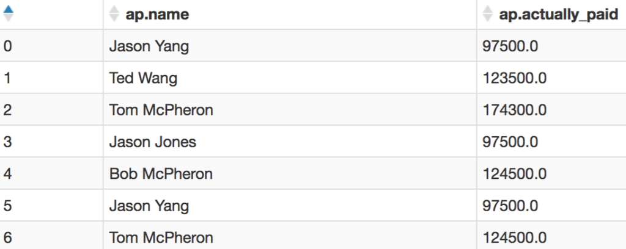

## 6.1 Another Form of `SELECT` Statement

```
SELECT ap.name, ap.Actually_Paid FROM
(
  SELECT name, salary, round(salary * (1 - deductions["Federal Taxes"] - deductions["State Taxes"] - deductions["Insurance"]), 1) as Actually_Paid
  FROM employees23
) ap
WHERE ap.Actually_Paid > 80000;
```

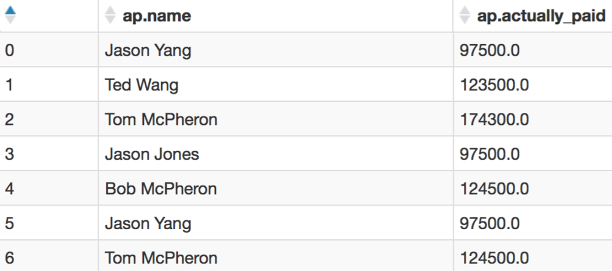

# 7 `CASE ... WHEN ... THEN` Statements

The `CASE ... WHEN ... THEN` clauses are like **if statements** for individual columns in a query

```
SELECT name, salary,
  CASE
    WHEN salary < 50000.0 THEN 'low'
    WHEN salary >= 50000.0 AND salary < 70000.0 THEN 'middle'
    WHEN salary >= 70000.0 AND salary < 100000.0 THEN 'high'
    ELSE 'very high'
  END AS bracket FROM employees23 LIMIT 5;
```

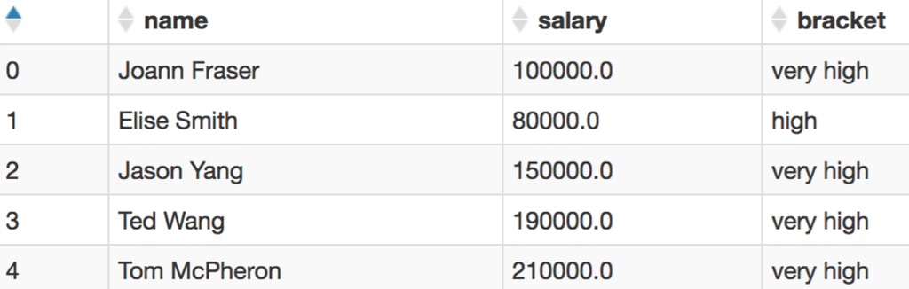

# 8 `LIKE` and `RLIKE` Operators

- The `LIKE` operator lets us match on strings that begin with or end with a particular substring, or when the substring appears anywhere within the string: `A LIKE B`
  - A LIKE `x%`: begins with the prefix `x` (%: any number of characters)
  - A LIKE `%x`: ends with the suffix `x`
  - A LIKE: `%x%`: begins with, ends with, or contains substring `x`
  - The underscore `_` matches a single character: `x_`, `_x`, and `_x_`
- The `RLIKE` operator lets us use Java regular expressions, a more powerful minilanguage for specifying matches: `A RLIKE B`
  - A RLIKE `.*(x|y).*`: begins with, ends with, or contains substring `x` or `y`

## 8.1 Some Examples Using `LIKE` and `RLIKE`

```
hive> select name, address.street from employees23
    > where address.street LIKE '%Ave.';
OK
Joann Fraser    100 Bay Ave.
John Smith  1 Michigan Ave.
Bob McPheron    12 Bush Ave.
Sam Johnson 1 Square Ave.
Tom McPheron    12 Bush Ave.
```

```
hive> select name, address.city from employees23
    > where address.city LIKE '%Be%';
OK
Joann Fraser    Long Beach
Elise Smith Long Beach
```

```
hive> select name, address.street from employees23
    > where address.street RLIKE '.*(Michigan|Ontario).*';
OK
John Smith  1 Michigan Ave.
Mary Smith  100 Ontario St.
Elise Smith 100 Ontario St.
```

# 9 More HiveQL Clauses/Statements

| Function | Description |
| --- | --- |
| `GROUP BY` | is used with aggregate functions to group the result by one or more columns and then does an aggregation over each group |
| `HAVING` | constrains the groups produced by `GROUP BY` |
| `INNER JOIN` | is only for equi-joins |
| `LEFT OUTER JOIN` | returns all records from left table plus those matching the `WHERE` clause |
| `RIGHT OUTER JOIN` | returns all records in right table plus those matching the `WHERE` clause |
| `FULL OUTER JOIN` | returns all records from all tables plus those matching the `WHERE` clause |
| `LEFT SEMI-JOIN` | returns records from left table if records are found in right table that satisfy the `ON` predicates |
| `Cartesian Product JOINs` | is not executed in parallel, not optimized using M/R |
| `MAP-SIDE JOINs` | do all joining on map-side and eliminate the reduce step |
| `ORDER BY` | is for a total ordering of the query result set in a single reducer (slow) |
| `SORT BY` | is for a local ordering within each reducer (faster) |
| `DISTRIBUTE BY` | controls how map output is divided among reducers |
| `CLUSTER BY` | is a short-hand way of `DISTRIBUTED BY... SORT BY` combination |
| `UNION ALL` | combines two or more tables |

## 9.1 Join Optimizations

- Hive assumes that the last table in the query is the largest
- It attempts to buffer the other tables and then stream the last table through, while performing joins on individual records
- You should structure your join queries so the largest table is last
- Fortunately, you don’t have to put the largest table last in the query. Hive also provides a “hint” mechanism to tell the query optimizer which table should be streamed

```
SELECT /*+ STREAMTABLE(s) */ ...;
```

## 9.2 LEFT SEMI-JOIN

Returns records from the left table if records are found in the right table that satisfy the `ON` predicates. It’s a special, optimized case of the more general inner join. For example, return stock records only on the days of dividend payments.

```
SELECT s.ymd, s.symbol, s.price_close
FROM stocks s LEFT SEMI JOIN dividends d
ON s.ymd = d.ymd AND s.symbol = d.symbol;
```

```
1985-04-25  ZAP 13.67
1985-01-09  ZAP 14.63
1984-10-09  ZAP 16.92
1984-07-09  ZAP 14.72
1984-04-09  ZAP 19.72
1984-01-09  ZAP 14.51
1983-10-07  ZAP 15.83
1983-07-11  ZAP 17.57
1983-04-11  ZAP 13.39
Time taken: 36.537 seconds, Fetched: 132722 row(s)
```

## 9.3 Map-side Joins

This is an optimization when all but one table is small. The largest table is streamed through the mappers while the small tables are cached in memory so that Hive can do all the joining on the mapside by looking up every possible match against the small tables in memory, thereby eliminating the reduce step required in common join scenarios. Processing is faster.

To do Map-side joins, first set a the following property to true:

```
set hive.auto.convert.join=true;
```

The join:

```
SELECT s.ymd, s.symbol, s.price_close, d.dividend
FROM stocks s JOIN dividends d ON s.ymd = d.ymd
AND s.symbol = d.symbol
WHERE s.symbol = 'IBM';
```

## 9.4 Example: `SORT BY`

```
hive> select s.ymd, s.symbol, s.price_close
    > from stocks s
    > sort by s.ymd asc, s.symbol desc
    > limit 18;
```

```
1962-01-02  KO  101.0
1962-01-02  IBM 572.0
1962-01-02  HPQ 35.0
1962-01-02  GE  74.75
1962-01-02  EK  110.75
1962-01-02  DIS 37.25
1962-01-02  DD  241.5
1962-01-02  CAT 38.5
1962-01-02  BA  50.0
1962-01-02  AA  65.37
1962-01-03  KO  98.75
1962-01-03  IBM 577.0
1962-01-03  HPQ 34.63
1962-01-03  GE  74.0
1962-01-03  EK  109.62
1962-01-03  DIS 37.75
1962-01-03  DD  241.75
1962-01-03  CAT 38.88
Time taken: 67.763 seconds, Fetched: 18 row(s)
```

## 9.5 `DISTRIBUTE BY` with `SORT BY`

These two clauses are often used together. In the following example, clause `DISTRIBUTE BY` is to ensure that the records for each stock symbol go to the same reducer, then use `SORT BY` to order the data.

```
SELECT s.ymd, s.symbol, s.price_close
FROM stocks s
DISTRIBUTE BY s.symbol
SORT BY s.symbol ASC, s.ymd ASC
limit 10;
```

```
1962-01-02  AA  65.37
1962-01-03  AA  66.37
1962-01-04  AA  66.37
1962-01-05  AA  66.25
1962-01-08  AA  64.0
1962-01-09  AA  63.75
1962-01-10  AA  63.88
1962-01-11  AA  63.5
1962-01-12  AA  62.0
1962-01-15  AA  60.75
Time taken: 62.771 seconds, Fetched: 10 row(s)
```

Note: `DISTRIBUTE BY` clause must come before the `SORT BY` clause

## 9.6 `CLUSTER BY = DISTRIBUTE BY` with `SORT BY`

`CLUSTER BY` clause is a shorthand way of expressing the same query on last slide

```
SELECT s.ymd, s.symbol, s.price_close
FROM stocks s
CLUSTER BY s.symbol, s.ymd
limit 10;
```

```
1962-01-02  AA  65.37
1962-01-03  AA  66.37
1962-01-04  AA  66.37
1962-01-05  AA  66.25
1962-01-08  AA  64.0
1962-01-09  AA  63.75
1962-01-10  AA  63.88
1962-01-11  AA  63.5
1962-01-12  AA  62.0
1962-01-15  AA  60.75
Time taken: 64.017 seconds, Fetched: 10 row(s)
```

## 9.7 List the Smaller Table Last

```
hive> select s.ymd, s.symbol, s.price_close, d.dividend
    > from stocks s JOIN dividends d ON s.ymd=d.ymd and s.symbol=d.symbol
    > where s.symbol='APL';
```

```
2002-12-27  APL 25.5    0.54
2002-09-26  APL 25.0    0.54
2002-06-26  APL 23.7    0.535
2002-03-26  APL 29.0    0.52
2001-12-27  APL 24.5    0.58
2001-09-26  APL 25.8    0.6
2001-06-27  APL 29.5    0.67
2001-03-28  APL 24.0    0.65
2000-12-27  APL 17.94   0.56
2000-09-27  APL 17.5    0.535
2000-06-28  APL 13.88   0.45
2000-03-29  APL 11.38   0.295
Time taken: 28.492 seconds, Fetched: 37 row(s)
```

## 9.8 List the Larger Table Last

```
hive> select s.ymd, s.symbol, s.price_close, d.dividend
    > from dividends d JOIN stocks s ON s.ymd=d.ymd and s.symbol=d.symbol
    > where s.symbol='APL';
```

```
2002-12-27  APL 25.5    0.54
2002-09-26  APL 25.0    0.54
2002-06-26  APL 23.7    0.535
2002-03-26  APL 29.0    0.52
2001-12-27  APL 24.5    0.58
2001-09-26  APL 25.8    0.6
2001-06-27  APL 29.5    0.67
2001-03-28  APL 24.0    0.65
2000-12-27  APL 17.94   0.56
2000-09-27  APL 17.5    0.535
2000-06-28  APL 13.88   0.45
2000-03-29  APL 11.38   0.295
Time taken: 23.732 seconds, Fetched: 37 row(s)
```

## 9.9 Use Hive “Hint” Mechanism to Optimize

```
hive> select /*+ STREAMTABLE(S) */ s.ymd, s.symbol, s.price_close, d.dividend
    > from stocks s JOIN dividends d ON s.ymd=d.ymd and s.symbol=d.symbol
    > where s.symbol='APL';
```

```
2002-12-27  APL 25.5    0.54
2002-09-26  APL 25.0    0.54
2002-06-26  APL 23.7    0.535
2002-03-26  APL 29.0    0.52
2001-12-27  APL 24.5    0.58
2001-09-26  APL 25.8    0.6
2001-06-27  APL 29.5    0.67
2001-03-28  APL 24.0    0.65
2000-12-27  APL 17.94   0.56
2000-09-27  APL 17.5    0.535
2000-06-28  APL 13.88   0.45
2000-03-29  APL 11.38   0.295
Time taken: 23.773 seconds, Fetched: 37 row(s)
```